# Date/Time & Time-series homework

```r
library(dplyr)
library(lubridate)
library(tidyverse)
library(tsibble)
library(tsibbledata)
library(feasts)
library(nycflights13)
```

```r
date1 <- ymd_hms("2017-04-22 22:01:18")
date2 <- ymd_hms("2001-11-07 10:09:56")
```

# Question 1

Extract the different components (year, month, mday, yday, wday) from the variable date1. Add the labels to the month and do not abbreviate the month labels.

```r
day1 <- day(date1)
month1 <- month(date1, label = TRUE, abbr = FALSE)
year1 <- year(date1)
day1_1 <- mday(date1)
day2_1 <- yday(date1)
day3_1 <- wday(date1, label = TRUE, abbr = FALSE, week_start = 1)
day1
```

```
[1] 22
```

```r
month1
```

```
[1] April
12 Levels: January < February < March < April < May < June < July < August < ... < December
```

```r
year1
```

```
[1] 2017
```

```r
day1_1
```

```
[1] 22
```

```r
day2_1
```

```
[1] 112
```

```r
day3_1
```

```
[1] Saturday
Levels: Monday < Tuesday < Wednesday < Thursday < Friday < Saturday < Sunday
```

# Question 2

Add 14 days to your date1 variable and store it in a variable called next_fortnight. Take away 10 years from your date2 variable, and store it in previous_decade.

```r
next_fortnight <- date1 + days(14)
previous_decade <- date2 - years(10)

next_fortnight
```

```
[1] "2017-05-06 22:01:18 UTC"
```

```r
previous_decade
```

```
[1] "1991-11-07 10:09:56 UTC"
```

# Question 3

Create a variable called this_year which contains today’s date. Then create an interval object which uses this_year and the previous_decade variable you made above. Store it in interval_years. Hint: you’ll need to use lubridate::interval in order to get the right function, as tsibble has one too.

```r
this_year <- today(tzone = "Europe/London")
interval_years <- lubridate::interval(this_year, previous_decade)
interval_years
```

```
[1] 2020-08-10 UTC--1991-11-07 10:09:56 UTC
```

# Question 4

Change the time zone of both your date variables to “America/New_York”, and call them nyc_date1 and nyc_date2.

```r
nyc_date1 <- ymd_hms(date1, tz = "America/New_York")
nyc_date2 <- ymd_hms(date2, tz = "America/New_York")
nyc_date1
```

```
[1] "2017-04-22 22:01:18 EDT"
```

```r
nyc_date2
```

```
[1] "2001-11-07 10:09:56 EST"
```

# Question 5

Use the flights data from the nycflights13 dataset. Make a date-time column called departure_date from the year, month, day, hour, and minute variables in the flights tibble.

```r
flights_dep_date <- flights %>%
  mutate(departure_date = make_datetime(year, month, day, hour, minute))
flights_dep_date
```

| year | month | day | dep_time | sched_dep_time | dep_delay | arr_time | sched_arr_time | arr_delay | carrier | flight | tailnum | origin | dest | air_time | distance | hour | minute | time_hour | departure_date |
| --- | --- | --- | --- | --- | --- | --- | --- | --- | --- | --- | --- | --- | --- | --- | --- | --- | --- | --- | --- |
| 2013 | 1 | 1 | 517 | 515 | 2 | 830 | 819 | 11 | UA | 1545 | N14228 | EWR | IAH | 227 | 1400 | 5 | 15 | 2013-01-01 05:00:00 | 2013-01-01 05:15:00 |
| 2013 | 1 | 1 | 533 | 529 | 4 | 850 | 830 | 20 | UA | 1714 | N24211 | LGA | IAH | 227 | 1416 | 5 | 29 | 2013-01-01 05:00:00 | 2013-01-01 05:29:00 |
| 2013 | 1 | 1 | 542 | 540 | 2 | 923 | 850 | 33 | AA | 1141 | N619AA | JFK | MIA | 160 | 1089 | 5 | 40 | 2013-01-01 05:00:00 | 2013-01-01 05:40:00 |
| 2013 | 1 | 1 | 544 | 545 | -1 | 1004 | 1022 | -18 | B6 | 725 | N804JB | JFK | BQN | 183 | 1576 | 5 | 45 | 2013-01-01 05:00:00 | 2013-01-01 05:45:00 |
| 2013 | 1 | 1 | 554 | 600 | -6 | 812 | 837 | -25 | DL | 461 | N668DN | LGA | ATL | 116 | 762 | 6 | 0 | 2013-01-01 06:00:00 | 2013-01-01 06:00:00 |
| 2013 | 1 | 1 | 554 | 558 | -4 | 740 | 728 | 12 | UA | 1696 | N39463 | EWR | ORD | 150 | 719 | 5 | 58 | 2013-01-01 05:00:00 | 2013-01-01 05:58:00 |
| 2013 | 1 | 1 | 555 | 600 | -5 | 913 | 854 | 19 | B6 | 507 | N516JB | EWR | FLL | 158 | 1065 | 6 | 0 | 2013-01-01 06:00:00 | 2013-01-01 06:00:00 |
| 2013 | 1 | 1 | 557 | 600 | -3 | 709 | 723 | -14 | EV | 5708 | N829AS | LGA | IAD | 53 | 229 | 6 | 0 | 2013-01-01 06:00:00 | 2013-01-01 06:00:00 |
| 2013 | 1 | 1 | 557 | 600 | -3 | 838 | 846 | -8 | B6 | 79 | N593JB | JFK | MCO | 140 | 944 | 6 | 0 | 2013-01-01 06:00:00 | 2013-01-01 06:00:00 |
| 2013 | 1 | 1 | 558 | 600 | -2 | 753 | 745 | 8 | AA | 301 | N3ALAA | LGA | ORD | 138 | 733 | 6 | 0 | 2013-01-01 06:00:00 | 2013-01-01 06:00:00 |

[output cut: 990 more lines]

# Question 6

Start with the weather data from the nycflights13 package. Select all the variables related to temperature, humidity, and precipitation, and pick out the key and index variables. Have a look at your data, and write a small description of the time series you observe.

| origin | time_hour | temp | humid | wind_dir | wind_speed | precip |
| --- | --- | --- | --- | --- | --- | --- |
| EWR | 2013-01-01 01:00:00 | 39.02 | 59.37 | 270 | 10.35702 | 0.00 |
| EWR | 2013-01-01 02:00:00 | 39.02 | 61.63 | 250 | 8.05546 | 0.00 |
| EWR | 2013-01-01 03:00:00 | 39.02 | 64.43 | 240 | 11.50780 | 0.00 |
| EWR | 2013-01-01 04:00:00 | 39.92 | 62.21 | 250 | 12.65858 | 0.00 |
| EWR | 2013-01-01 05:00:00 | 39.02 | 64.43 | 260 | 12.65858 | 0.00 |
| EWR | 2013-01-01 06:00:00 | 37.94 | 67.21 | 240 | 11.50780 | 0.00 |
| EWR | 2013-01-01 07:00:00 | 39.02 | 64.43 | 240 | 14.96014 | 0.00 |
| EWR | 2013-01-01 08:00:00 | 39.92 | 62.21 | 250 | 10.35702 | 0.00 |
| EWR | 2013-01-01 09:00:00 | 39.92 | 62.21 | 260 | 14.96014 | 0.00 |
| EWR | 2013-01-01 10:00:00 | 41.00 | 59.65 | 260 | 13.80936 | 0.00 |

[output cut: 990 more lines]

Weather data is collected once an hour, temperature, dew point, wind direction and speed, precipitation, pressure and visibility are recorded. Some other data not related to weather is also recorded.

# Question 7

Change the weather data into a tsibble. Hint, look up in the notes where we suggest using as_tsibble function. You’ll need to define an index and key.

```r
weather_data <- as_tsibble(weather_data, key = origin, index = time_hour)
weather_data
```

| origin | time_hour | temp | humid | wind_dir | wind_speed | precip |
| --- | --- | --- | --- | --- | --- | --- |
| EWR | 2013-01-01 01:00:00 | 39.02 | 59.37 | 270 | 10.35702 | 0.00 |
| EWR | 2013-01-01 02:00:00 | 39.02 | 61.63 | 250 | 8.05546 | 0.00 |
| EWR | 2013-01-01 03:00:00 | 39.02 | 64.43 | 240 | 11.50780 | 0.00 |
| EWR | 2013-01-01 04:00:00 | 39.92 | 62.21 | 250 | 12.65858 | 0.00 |
| EWR | 2013-01-01 05:00:00 | 39.02 | 64.43 | 260 | 12.65858 | 0.00 |
| EWR | 2013-01-01 06:00:00 | 37.94 | 67.21 | 240 | 11.50780 | 0.00 |
| EWR | 2013-01-01 07:00:00 | 39.02 | 64.43 | 240 | 14.96014 | 0.00 |
| EWR | 2013-01-01 08:00:00 | 39.92 | 62.21 | 250 | 10.35702 | 0.00 |
| EWR | 2013-01-01 09:00:00 | 39.92 | 62.21 | 260 | 14.96014 | 0.00 |
| EWR | 2013-01-01 10:00:00 | 41.00 | 59.65 | 260 | 13.80936 | 0.00 |

[output cut: 990 more lines]

#Question 8.

Add a year and month column to your new tsibble weather data, and create a basic line plot which shows the temperature data from each airport over time. Have a think back to what you learned in visualisation week, and think about whether plotting the whole time series in one go is adequate here? Write down your suggestions for what could be done to make a better and more informative plot.

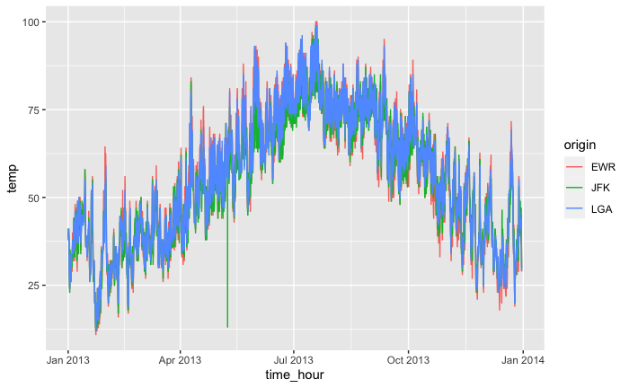

Plotting all datapoints for all three airports on the same graph makes little sense, as the lines overlap, which makes te chart hard to read. Two possible solutions - either split it into three charts, displaying data from one airport on aech chart. However better solution is to use fewer datapoints.

```r
weather_data_y_m_agg <- weather_data_y_m %>%
  index_by(date = ~yday(.)) %>%
  summarise(temp_mean = mean(temp, na.rm = TRUE))
weather_data_y_m_agg
```

| date | temp_mean |
| --- | --- |
| 1 | 36.99970 |
| 2 | 28.70250 |
| 3 | 29.97250 |
| 4 | 34.94000 |
| 5 | 37.20500 |
| 6 | 40.05183 |
| 7 | 40.58250 |
| 8 | 40.11750 |
| 9 | 43.22500 |
| 10 | 43.85000 |

[output cut: 354 more lines]

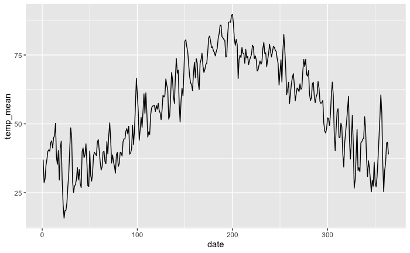

```r
ggplot(weather_data_y_m_agg) +
  aes(x = date, y = temp_mean) +
  geom_line(group = 1)
```

# Question 9

Choose an appropriate rolling window and calculate a moving average for your weather temperature data for each airport origin. Create a useful plot which overlays the original time series data and the rolling average data. Make sure the graph is easy for others to understand (Hint: you might want to facet_wrap). Finally, write a summary of why you chose the time window you did, and describe any trends you see.

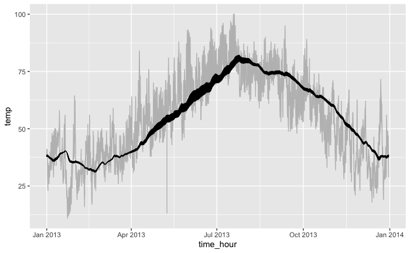

# Question 10

Downsample your data so that you plot daily temperature data for each airport, instead of hourly data.

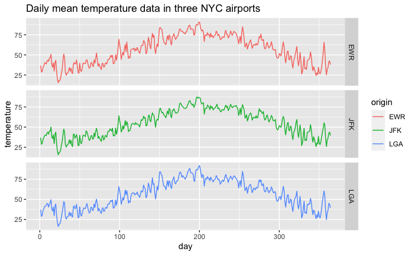